# Assignment 2

Hari Subhash Mario

Date created: 2019-04-18

## Background

**PROBLEM:** Here, the problem is that flight delays are unpredictable. Not only that, mis-timing your ride to the airport could be costly; Arrive late and you may miss your flight altogether, but arrive early and you’ll spend even more uncomfortable, unproductive time at the gate

**GOAL:** My ultimate goal is to be able to best predict a flight’s departure delay. In an ideal world, all flights would simply leave on time. In a second-best world, each airline would contact travelers directly with flight delay information that was accurate and timely enough to be actionable. Alas, neither of those are the case and so in the world we live in, my goal is to better predict delay using weather and flight data.

**HYPOTHESIS:** My null hypothesis is that *no* available weather or flight data shares a relationship with flight delay.

## Setting up

To set up, I’ll do the following:

```r
# This line enables relevant packages
library(tidyverse); library(skimr); library(nycflights13); library(lubridate); library(ggthemes)
```

## Univariate analysis

Here’s what I’ll look at for each variable:

- Metadata will explain what each variable represents
- Descriptive variables including number of observations, mean, standard deviation, median, min, max, and interquartile measures
- A histogram will offer a visual representation of each

Doing this will expose:

- Fields that would be unlikely related to departure delay,
- Fields that will require transformation, and
- Fields with too few observations or with too many missing observations to be representative

```r
skim(flt_wx_raw)
```

```
Skim summary statistics
 n obs: 336776
 n variables: 32

-- Variable type:character -----------------------------------------------------
 variable missing complete      n min max empty n_unique
  carrier       0   336776 336776   2   2     0       16
     dest       0   336776 336776   3   3     0      105
   origin       0   336776 336776   3   3     0        3
  tailnum    2512   334264 336776   5   6     0     4043

-- Variable type:integer -------------------------------------------------------
       variable missing complete      n    mean      sd   p0  p25  p50  p75 p100     hist
       arr_time    8713   328063 336776 1502.05  533.26    1 1104 1535 1940 2400 ▁▁▃▇▆▆▇▆
          day.x       0   336776 336776   15.71    8.77    1    8   16   23   31 ▇▇▇▇▆▇▇▇
          day.y    1556   335220 336776   15.67    8.74    1    8   16   23   31 ▇▇▇▇▆▇▇▆
       dep_time    8255   328521 336776 1349.11  488.28    1  907 1401 1744 2400 ▁▁▇▆▆▇▆▂
         flight       0   336776 336776 1971.92 1632.47    1  553 1496 3465 8500 ▇▅▂▃▂▁▁▁
         hour.y    1556   335220 336776   13.17    4.66    1    9   13   17   23 ▁▃▇▆▅▇▇▂
        month.x       0   336776 336776    6.55    3.41    1    4    7   10   12 ▇▅▇▃▅▇▅▇
 sched_arr_time       0   336776 336776 1536.38  497.46    1 1124 1556 1945 2359 ▁▁▂▇▆▇▇▆
 sched_dep_time       0   336776 336776 1344.25  467.34  106  906 1359 1729 2359 ▁▃▇▆▆▇▇▂
         year.x       0   336776 336776 2013       0    2013 2013 2013 2013 2013 ▁▁▁▇▁▁▁▁

-- Variable type:numeric -------------------------------------------------------
   variable missing complete      n      mean      sd      p0     p25     p50     p75    p100     hist
   air_time    9430   327346 336776  150.69    93.69    20      82     129     192     695    ▇▇▂▃▁▁▁▁
  arr_delay    9430   327346 336776    6.9     44.63   -86     -17      -5      14    1272    ▇▁▁▁▁▁▁▁
  dep_delay    8255   328521 336776   15.39    39.01     0       0       0      11    1301    ▇▁▁▁▁▁▁▁
       dewp    1573   335203 336776   41.63    19.35    -9.94   26.06   42.8    57.92   78.08 ▁▃▆▇▇▇▇▅
   distance       0   336776 336776 1039.91   733.23    17     502     872    1389    4983    ▆▇▂▂▁▁▁▁
     hour.x       0   336776 336776   13.18     4.66     1       9      13      17      23    ▁▃▇▆▅▇▇▂
      humid    1573   335203 336776   59.56    19.66    12.74   43.99   57.73   75.33  100    ▁▃▇▇▇▆▆▃
     minute       0   336776 336776   26.23    19.3      0       8      29      44      59    ▇▂▃▃▅▂▃▅
    month.y    1556   335220 336776    6.53     3.41     1       4       7       9      12    ▇▅▇▃▅▇▅▇
     precip    1556   335220 336776    0.0046   0.031    0       0       0       0       1.21 ▇▁▁▁▁▁▁▁
   pressure   38788   297988 336776 1017.81     7.45   983.8  1012.7  1017.5  1022.8  1042.1  ▁▁▁▅▇▆▂▁
       temp    1573   335203 336776   57       17.96    10.94   42.08   57.2    71.96  100.04 ▁▃▇▇▇▇▅▁
      visib    1556   335220 336776    9.26     2.03     0      10      10      10      10    ▁▁▁▁▁▁▁▇
   wind_dir    9796   326980 336776  201.54   104.82     0     130     220     290     360    ▅▃▂▆▅▇▇▆
  wind_gust  256391    80385 336776   25.25     5.98    16.11   20.71   24.17   28.77   66.75 ▇▇▂▁▁▁▁▁
 wind_speed    1634   335142 336776   11.11     5.57     0       6.9    10.36   14.96   42.58 ▂▇▆▃▁▁▁▁
     year.y    1556   335220 336776 2013        0     2013    2013    2013    2013    2013    ▁▁▁▇▁▁▁▁

-- Variable type:POSIXct -------------------------------------------------------
  variable missing complete      n        min        max     median n_unique
 time_hour       0   336776 336776 2013-01-01 2013-12-31 2013-07-03     6936
```

The following fields are either unlikely to be related to departure delay or duplicative of another, superior field in the data set

- Destination
- Tail number
- Arrival time
- Day of the month
- Flight number
- Scheduled arrival time
- Year
- Air time
- Arrival delay
- Departure time
- Distance

The following fields will need to be transformed in the succeeding ways:

- Departure delay – replace negative values with 0
- Carrier – Use difference between the mean delay of flights by a single carrier with mean delay overall
- Origin – Use difference between the mean delay of flights that originate at a single airport with mean delay overall
- Time_hour – Extract day of the week and convert to a dummy variable for whether the day is a weekend day
- Scheduled departure time – Use difference with the hour of day of peak delays
- Month – Use difference with the month of peak delays

Only one field among those remaining, **wind gust**, is concerning due to the number of n/a entries. My fear is that these incomplete entries are biased – that is, we may be telling a story that is based on a sample of the data that does not represent the poopulation.

```r
flt_wx_raw %>%
  select(wind_gust,dep_delay) %>%
  filter(is.na(dep_delay) == F) %>%
  mutate(na_gust = if_else(is.na(wind_gust), 0, 1)) %>%
  group_by(na_gust) %>% ## Here, I split up all entries based on whether or not wind_gust is NULL
  summarise(mean_del = mean(dep_delay,na.rm = T) ## Starting here, I look at descriptive statistics by NULL or not
     ,n_del     = length(dep_delay)
     ,mean_del   = mean(dep_delay,na.rm = T)
     ,stdev_del  = sd(dep_delay,na.rm = T)
     ,min_del    = min(dep_delay,na.rm = T)
     ,del_25qile = quantile(dep_delay,probs = 0.25,na.rm = T)
     ,mdn_del    = median(dep_delay,na.rm = T)
     ,del_75qile = quantile(dep_delay,probs = 0.75,na.rm = T)
     ,max_del    = max(dep_delay, na.rm = T))
    round(2)

flt_wx_raw %>%
  select(wind_gust,dep_delay) %>%
  filter(is.na(dep_delay) == F) %>%
  mutate(na_gust = if_else(is.na(wind_gust), 0, 1)) %>%
  ggplot(aes(dep_delay)) +
  geom_density() +
  ggtitle(label = 'Dep. delay differs when wind gust is na but not by much') +
  theme_fivethirtyeight() +
  facet_wrap(~na_gust, nrow = 2, ncol = 1)
```

[output not shown]

These look similar enough to work with. To verify with numbers, I would do a z-test to see if I’m able to disprove that the means are unequal and an f-test to do the same with the standard deviations. But not today. Today, I will do neither.

Now to filter out the unused fields and transform other fields:

```r
skim(flt_wx_cln)
```

```
Skim summary statistics
 n obs: 336776
 n variables: 15

-- Variable type:numeric -------------------------------------------------------
   variable missing complete      n      mean      sd     p0     p25     p50     p75    p100     hist
 carr_delay       0   336776 336776    2.8      4.18   -4.7    -0.7     1.7     6.28   10.04 ▂▁▇▇▅▁▂▅
  dep_delay    8255   328521 336776   15.39    39.01    0       0       0      11    1301    ▇▁▁▁▁▁▁▁
       dewp    1573   335203 336776   41.63    19.35   -9.94   26.06   42.8    57.92   78.08 ▁▃▆▇▇▇▇▅
  diff_20hr       0   336776 336776  636.02   438.41    0     238     601    1054    1854    ▇▆▅▃▆▅▁▁
   diff_7mo       0   336776 336776    2.95     1.78    0       1       3       4       6    ▅▇▇▇▁▇▇▃
      humid    1573   335203 336776   59.56    19.66   12.74   43.99   57.73   75.33  100    ▁▃▇▇▇▆▆▃
   is_wkend       0   336776 336776    0.25     0.43    0       0       0       1       1    ▇▁▁▁▁▁▁▃
  ogn_delay       0   336776 336776    2.75     1.59    1.18    1.18    1.98    4.84    4.84 ▇▇▁▁▁▁▁▇
     precip    1556   335220 336776    0.0046   0.031   0       0       0       0       1.21 ▇▁▁▁▁▁▁▁
   pressure   38788   297988 336776 1017.81     7.45  983.8  1012.7  1017.5  1022.8  1042.1  ▁▁▁▅▇▆▂▁
       temp    1573   335203 336776   57       17.96   10.94   42.08   57.2    71.96  100.04 ▁▃▇▇▇▇▅▁
      visib    1556   335220 336776    9.26     2.03    0      10      10      10      10    ▁▁▁▁▁▁▁▇
   wind_dir    9796   326980 336776  201.54   104.82    0     130     220     290     360    ▅▃▂▆▅▇▇▆
  wind_gust  256391    80385 336776   25.25     5.98   16.11   20.71   24.17   28.77   66.75 ▇▇▂▁▁▁▁▁
 wind_speed    1634   335142 336776   11.11     5.57    0       6.9    10.36   14.96   42.58 ▂▇▆▃▁▁▁▁
```

## Bivariate analysis

There are steps here

1. Scatter plots to intuit relationships to explore
2. Find correlation
3. Linear model the best

**LINEAR RELATIONSHIPS:** I’m looking for scatter plots that appear generally linear with as little spread around the line as possible

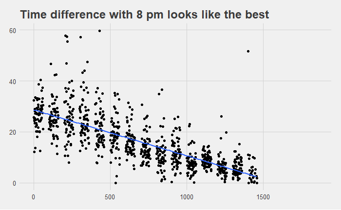

The variables that appear to have the best relationships with dep_delay are:

1. diff_20hr (the best by far),
2. humid,
3. pressure,
4. carr_delay, and
5. dewp

One initial concern I have is that humidity and dewpoint are telling the same part of the story.

For now, let’s shrink our working data frame for the last time to the remaining variables we still care about.

**OUTLIERS:**

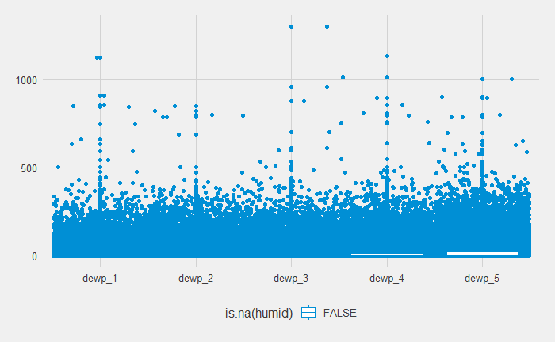

**CORRELATION:** Now that we’ve picked our independent variables, I’ll verify using correlation

Correlation measures the degree to which two variables move up or down in relation to each other. Correlation must fall somewhere between -1.00 and 1.00, which imply a perfectly negative relationship and a perfectly positive relationship, respectively.

And now correlation.

| variable | corr_dep_delay |
| --- | --- |
| diff_20hr | -0.19 |
| humid | 0.11 |
| pressure | -0.11 |
| carr_delay | 0.11 |
| dewp | 0.10 |

As predicted, diff_20hr has the best relationship with corr_dep_delay. Though it doesn’t appear that the magnitude of any correlations is very high.

**LINEAR MODEL:** Having confirmed diff_20hr as the variable to use, we can let R build a linear model.

```r
  lm(dep_delay ~ diff_20hr, data = flt_wx)
```

```
Call:
lm(formula = dep_delay ~ diff_20hr, data = flt_wx)

Coefficients:
(Intercept)    diff_20hr
   26.43344     -0.01726
```

## Multivariate analysis

1. Covariance
2. Linear model multiple